# Using Classification (Logistic Regression) for Prediction

Classification is the process of predicting group membership. Understanding which individuals are likely to be members of which groups is a key task for data scientists. For instance, most recommendation engines that are at the heart of consumer web sites are based on classification algorithms, predicting which consumers are likely to purchase which products.

## Pizza

Today we’ll be working with the pizza dataset, which comes from the subreddit random acts of pizza. Each line represents a post to this subreddit. We have various characteristics of these posts, along with the request text from the post itself. We’ll use these characteristics of the posts to predict whether or not the poster received pizza. This lesson is inspired by [this article](http://www.aaai.org/ocs/index.php/ICWSM/ICWSM14/paper/download/8106/8101)

```r
library(knitr)
library(tidyverse)
library(modelr)
library(yardstick)
library(tidymodels)
library(probably)
load("za.Rdata")

za$gotpiz_factor<-as.factor(za$got_pizza)
za$karma<-as.character(za$karma)
za$karma<-as.numeric(za$karma)
```

| name | Description |
| --- | --- |
| got_pizza | Did the person who posted get pizza? 1=Yes, 0=No |
| got_pizza_f | Did the person who posted get pizza “Yes” or “No” (factor) |
| karma | The redditor’s total upvotes on Reddit. |
| age | How long has the user been on Reddit (in days). |
| raop_age | How long has the user been posting on Random Acts of Pizza (raop) (in days). |
| pop_request | How popular was this request? |
| activity | How many comments for this request? |
| total_posts | How many times has the user posted on Reddit? |
| raop_posts | How many times has the user posted on Random Acts of Pizza? |
| prev_raop_post | Has the person posted previously on the subreddit? |
| words | Number of words in the request |
| poor | Word “poor” appears in the post |
| student | Word “student” appears in the post |
| grateful | Word “grateful” appears in the post |
| score | Sentiment score, more positive words+, more negative words - |

```r
#Let's examine our dataset summary
summary(za)
```

```
##    got_pizza      got_pizza_f     karma             age
##  Min.   :0.0000   No  :4273   Min.   :  -173   Min.   :   0.000
##  1st Qu.:0.0000   Yes :1397   1st Qu.:     3   1st Qu.:   3.585
##  Median :0.0000   NA's:   3   Median :   170   Median : 155.570
##  Mean   :0.2464               Mean   :  1164   Mean   : 252.827
##  3rd Qu.:0.0000               3rd Qu.:  1160   3rd Qu.: 386.691
##  Max.   :1.0000               Max.   :155010   Max.   :2809.751
##  NA's   :3                    NA's   :3        NA's   :2
##     raop_age       pop_request         activity          total_posts
##  Min.   :  0.00   Min.   :  0.000   Min.   :0.000e+00   Min.   :   0.00
##  1st Qu.:  0.00   1st Qu.:  2.000   1st Qu.:1.000e+00   1st Qu.:   0.00
##  Median :  0.00   Median :  4.000   Median :1.100e+01   Median :   5.00
##  Mean   : 16.56   Mean   :  6.401   Mean   :2.435e+05   Mean   :  21.54
##  3rd Qu.:  0.00   3rd Qu.:  7.000   3rd Qu.:2.700e+01   3rd Qu.:  22.00
##  Max.   :785.46   Max.   :414.000   Max.   :1.381e+09   Max.   :1125.00
##  NA's   :2        NA's   :1         NA's   :2           NA's   :2
##    raop_posts            prev_raop_post     words
##  Min.   :0.00000   First Post   :5420   Min.   :   1.00
##  1st Qu.:0.00000   Posted Before: 250   1st Qu.:  36.00
##  Median :0.00000   NA's         :   3   Median :  61.00
##  Mean   :0.05785                        Mean   :  79.73
##  3rd Qu.:0.00000                        3rd Qu.:  99.00
##  Max.   :5.00000                        Max.   :1411.00
##  NA's   :3                              NA's   :160
##                poor            student                     grateful
##  Poor not in post:5528   No student:5227   Grateful not in post:5485
##  Poor in post    : 145   Student   : 446   Grateful in post    : 188
##
##
##
##
##
##      score          gotpiz_factor
##  Min.   :-52.0000   0   :4273
##  1st Qu.: -1.0000   1   :1397
##  Median :  0.0000   NA's:   3
##  Mean   :  0.9071
##  3rd Qu.:  3.0000
##  Max.   : 29.0000
##  NA's   :12
```

```r
#take note of the missing data - if data is missing on key variables, we may want to omit this data from our descriptive statistics plots/tables
```

## Conditional Means as a Classifier

We’ll start by generating some cross tabs and some quick plots, showing the probability of receiving pizza according to several characteristics of the post. We start with a basic crosstab of the dependent variable. We use `prop.table` to change this from raw counts to proportions. I also provide a brief example of how to do a table using the `kable` function.

```r
#Crosstabs
za%>%
  count(got_pizza)%>% # Count numbers getting pizza
  mutate(p=prop.table(n))#%>% #mutate for proportions using prop.table
```

```
## # A tibble: 3 × 3
##   got_pizza     n        p
##       <dbl> <int>    <dbl>
## 1         0  4273 0.753
## 2         1  1397 0.246
## 3        NA     3 0.000529
```

```r
  #kable(format="markdown") # output to table

#Note - here's a place where I don't want NAs included. I want my proportions to be calculated from my VALID N (the non-missing data), so I'm going to filter out missing and then re-run my table:
za%>%
  filter(!is.na(got_pizza))%>%
  count(got_pizza)%>% # Count numbers getting pizza
  mutate(p=prop.table(n))#%>% #mutate for proportions using prop.table
```

```
## # A tibble: 2 × 3
##   got_pizza     n     p
##       <dbl> <int> <dbl>
## 1         0  4273 0.754
## 2         1  1397 0.246
```

```r
 # kable(format="markdown") # output to table

#because there isn't very much missingness on my got_pizza var (only 3 missing values), my proportions don't change all that much - but these are more accurate. I'm going to filter out missing for all future plots

exampledata<-za%>%
  filter(!is.na(got_pizza))
```

So, about 75% of the sample didn’t get pizza, about 25% did. This isn’t *ideal* representation of values, but it’s what we have.

Next, we cross-tabulate receiving pizza with certain terms. First, if the request mentioned the word “student.”

```r
za%>%
  filter(!is.na(got_pizza))%>% #we could also just use 'exampledata'
  group_by(student, got_pizza)%>%
  summarize(n=n())%>%
  mutate(prop=n/sum(n))%>%
  subset(select=c("student","got_pizza","prop"))%>%
  spread(got_pizza,prop)#%>%
```

```
## # A tibble: 2 × 3
## # Groups:   student [2]
##   student      `0`   `1`
##   <fct>      <dbl> <dbl>
## 1 No student 0.758 0.242
## 2 Student    0.702 0.298
```

```r
  #kable()
```

Next, if the request mentioned the word “grateful.”

```r
za%>%
  filter(!is.na(got_pizza))%>%
  group_by(grateful, got_pizza)%>%
  summarize(n=n())%>%
  mutate(prop=n/sum(n))%>%
  subset(select=c("grateful","got_pizza","prop"))%>%
  spread(got_pizza,prop)#%>%
```

```
## # A tibble: 2 × 3
## # Groups:   grateful [2]
##   grateful               `0`   `1`
##   <fct>                <dbl> <dbl>
## 1 Grateful not in post 0.756 0.244
## 2 Grateful in post     0.697 0.303
```

```r
 # kable()

#ad in crosstab with poor
za%>%
  filter(!is.na(got_pizza))%>%
  group_by(poor, got_pizza)%>%
  summarize(n=n())%>%
  mutate(prop=n/sum(n))%>%
  subset(select=c("poor","got_pizza","prop"))%>%
  spread(got_pizza, prop)#%>%
```

```
## # A tibble: 2 × 3
## # Groups:   poor [2]
##   poor               `0`   `1`
##   <fct>            <dbl> <dbl>
## 1 Poor not in post 0.754 0.246
## 2 Poor in post     0.745 0.255
```

```r
  #kable()
```

Crosstabs using binary data are equivalent to generating conditional means, as shown below.

```r
#Predictions using conditional means
za%>%
  group_by(grateful)%>%
  summarize(mean(got_pizza, na.rm=T)) #the na.rm removes any missing on our got_pizza var, so I didn't bother filtering it out like I did above when I was calculating the means "by hand"
```

```
## # A tibble: 2 × 2
##   grateful             `mean(got_pizza, na.rm = T)`
##   <fct>                                       <dbl>
## 1 Grateful not in post                        0.244
## 2 Grateful in post                            0.303
```

```r
#Note: this only works because we are dealing with a binary variable.
za%>%
  group_by(grateful)%>%
  summarize(no_pizza= 1 - mean(got_pizza, na.rm = T),
            got_pizza = mean(got_pizza, na.rm=T))#%>%
```

```
## # A tibble: 2 × 3
##   grateful             no_pizza got_pizza
##   <fct>                   <dbl>     <dbl>
## 1 Grateful not in post    0.756     0.244
## 2 Grateful in post        0.697     0.303
```

```r
 # kable()
```

We can also use conditional means to get proportions for very particular sets of characteristics. In this case, what about individuals who included some combination of the terms “grateful”,“student” and “poor” in their posts?

```r
za%>%
  group_by(grateful, student)%>%
  summarize(mean_pizza=mean(got_pizza, na.rm=T))%>%
  arrange(-mean_pizza)
```

```
## # A tibble: 4 × 3
## # Groups:   grateful [2]
##   grateful             student    mean_pizza
##   <fct>                <fct>           <dbl>
## 1 Grateful in post     Student         0.474
## 2 Grateful not in post Student         0.290
## 3 Grateful in post     No student      0.284
## 4 Grateful not in post No student      0.241
```

```r
za_sum<-za%>%
  group_by(grateful, student, poor)%>%
  summarize(mean_pizza=mean(got_pizza, na.rm=T))%>%
  arrange(-mean_pizza)
#kable(za_sum)
```

## Probability of Receiving Pizza, Using Various Terms in Post

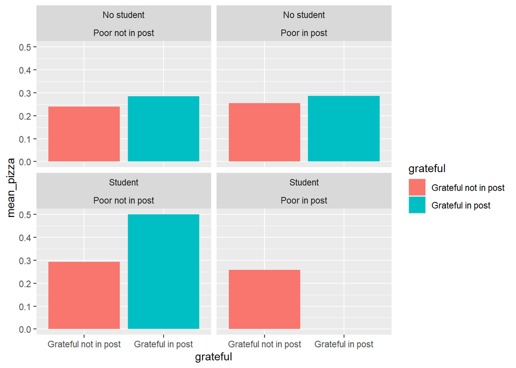

```r
gg<-ggplot(za_sum, aes(x=grateful, y=mean_pizza, fill=grateful)) +
  geom_bar(stat="identity") +
  facet_wrap(~student + poor)
gg
```

We (the person reading the plot) should make note of how many cases make up each grouping. As we continue to bin by more and more variables, we risk creating bins too small to be representative of the true probabilities.

```r
za%>%
  group_by(grateful, student, poor)%>%
  summarize(mean_pizza=mean(got_pizza, na.rm=T),
            n_cases = n())%>%
  arrange(-mean_pizza)#%>%
```

```
## # A tibble: 8 × 5
## # Groups:   grateful, student [4]
##   grateful             student    poor             mean_pizza n_cases
##   <fct>                <fct>      <fct>                 <dbl>   <int>
## 1 Grateful in post     Student    Poor not in post      0.5        18
## 2 Grateful not in post Student    Poor not in post      0.293     392
## 3 Grateful in post     No student Poor in post          0.286       7
## 4 Grateful in post     No student Poor not in post      0.284     162
## 5 Grateful not in post Student    Poor in post          0.257      35
## 6 Grateful not in post No student Poor in post          0.255     102
## 7 Grateful not in post No student Poor not in post      0.240    4956
## 8 Grateful in post     Student    Poor in post          0           1
```

```r
  #kable()
```

## Logistic regression as a classifier

Logistic regression is set up to handle binary outcomes as the dependent variable. The downside to logistic regression is that it is modeling the log odds of the outcome, which means all of the coefficients are expressed as log odds, which no one understands intuitively.

Remember the “tidymodels” approach to modeling that we have already gone over for linear regression: 1. Data Exploration 2. Split the Data 3. Begin a Workflow 4. Specify the Formula 5. Specify the Model 6. Set/Update Recipe 7. Assemble Workflow 8. Fit the Model to the Data 9. Predict the Testing Data 10. Calculate Fit Repeat Steps 4-10 as needed

### Step 1: Data Exploration

#### The Data

We already took a preliminary look at the data.

```r
summary(za)
```

```
##    got_pizza      got_pizza_f     karma             age
##  Min.   :0.0000   No  :4273   Min.   :  -173   Min.   :   0.000
##  1st Qu.:0.0000   Yes :1397   1st Qu.:     3   1st Qu.:   3.585
##  Median :0.0000   NA's:   3   Median :   170   Median : 155.570
##  Mean   :0.2464               Mean   :  1164   Mean   : 252.827
##  3rd Qu.:0.0000               3rd Qu.:  1160   3rd Qu.: 386.691
##  Max.   :1.0000               Max.   :155010   Max.   :2809.751
##  NA's   :3                    NA's   :3        NA's   :2
##     raop_age       pop_request         activity          total_posts
##  Min.   :  0.00   Min.   :  0.000   Min.   :0.000e+00   Min.   :   0.00
##  1st Qu.:  0.00   1st Qu.:  2.000   1st Qu.:1.000e+00   1st Qu.:   0.00
##  Median :  0.00   Median :  4.000   Median :1.100e+01   Median :   5.00
##  Mean   : 16.56   Mean   :  6.401   Mean   :2.435e+05   Mean   :  21.54
##  3rd Qu.:  0.00   3rd Qu.:  7.000   3rd Qu.:2.700e+01   3rd Qu.:  22.00
##  Max.   :785.46   Max.   :414.000   Max.   :1.381e+09   Max.   :1125.00
##  NA's   :2        NA's   :1         NA's   :2           NA's   :2
##    raop_posts            prev_raop_post     words
##  Min.   :0.00000   First Post   :5420   Min.   :   1.00
##  1st Qu.:0.00000   Posted Before: 250   1st Qu.:  36.00
##  Median :0.00000   NA's         :   3   Median :  61.00
##  Mean   :0.05785                        Mean   :  79.73
##  3rd Qu.:0.00000                        3rd Qu.:  99.00
##  Max.   :5.00000                        Max.   :1411.00
##  NA's   :3                              NA's   :160
##                poor            student                     grateful
##  Poor not in post:5528   No student:5227   Grateful not in post:5485
##  Poor in post    : 145   Student   : 446   Grateful in post    : 188
##
##
##
##
##
##      score          gotpiz_factor
##  Min.   :-52.0000   0   :4273
##  1st Qu.: -1.0000   1   :1397
##  Median :  0.0000   NA's:   3
##  Mean   :  0.9071
##  3rd Qu.:  3.0000
##  Max.   : 29.0000
##  NA's   :12
```

I am telling you now that we will be modeling today with to predict `got_pizza_f` with

`age`,

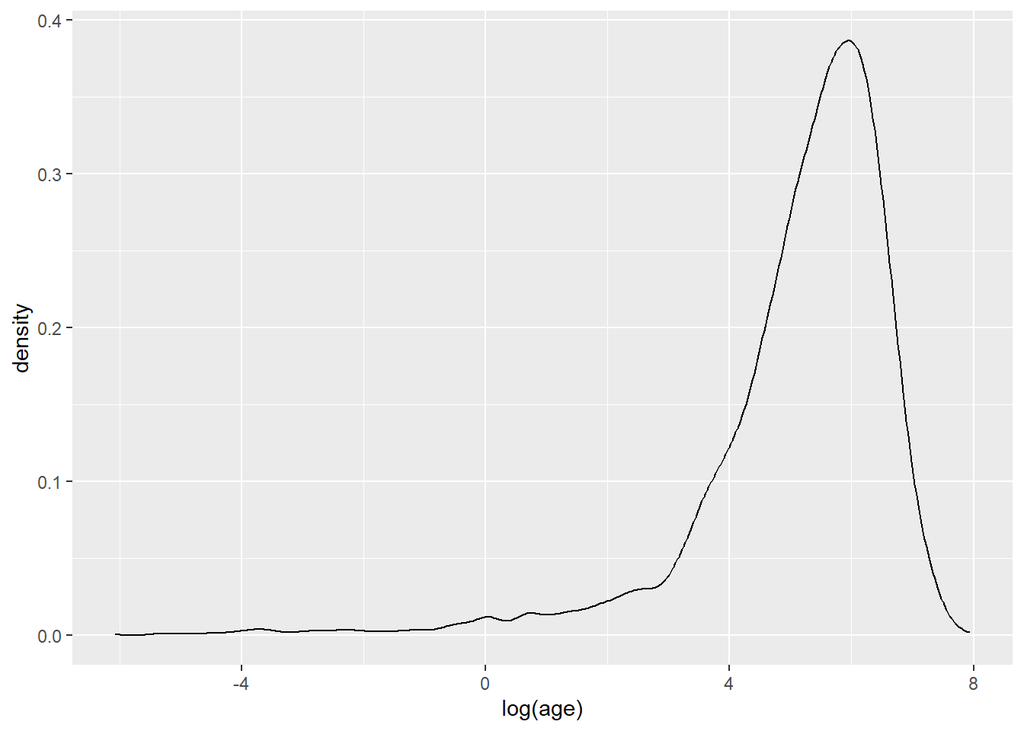

```r
gg<-ggplot(za, aes(x=log(age)))+
  geom_density()
gg
```

`karma`,

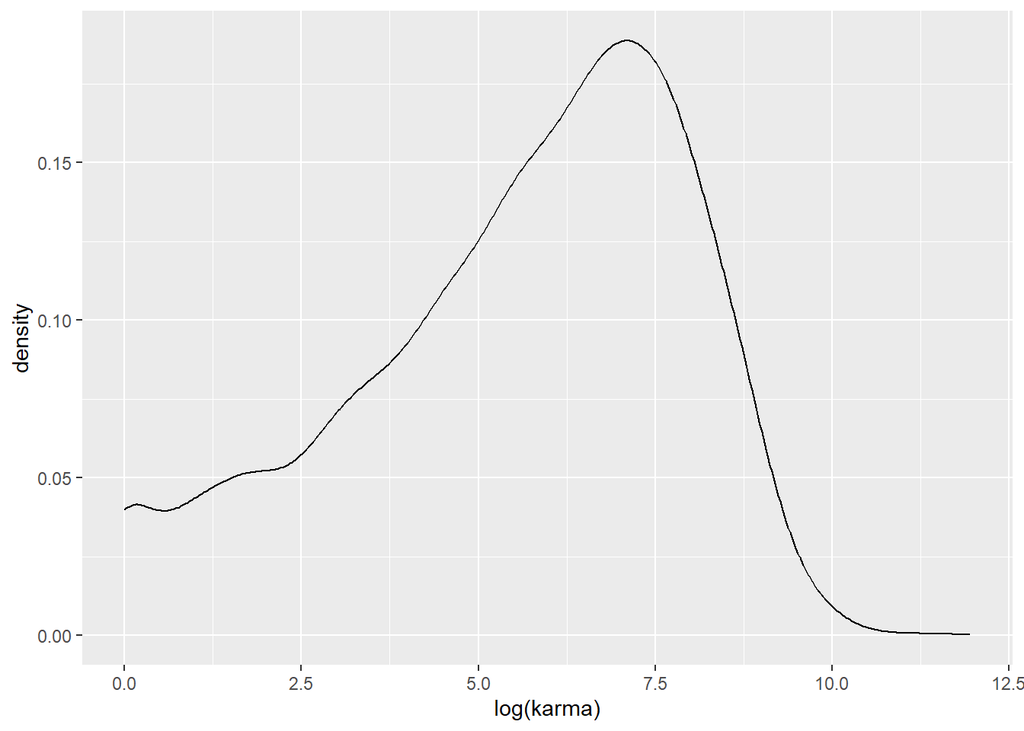

```r
gg<-ggplot(za, aes(x=log(karma)))+
  geom_density()
gg
```

`total_posts`,

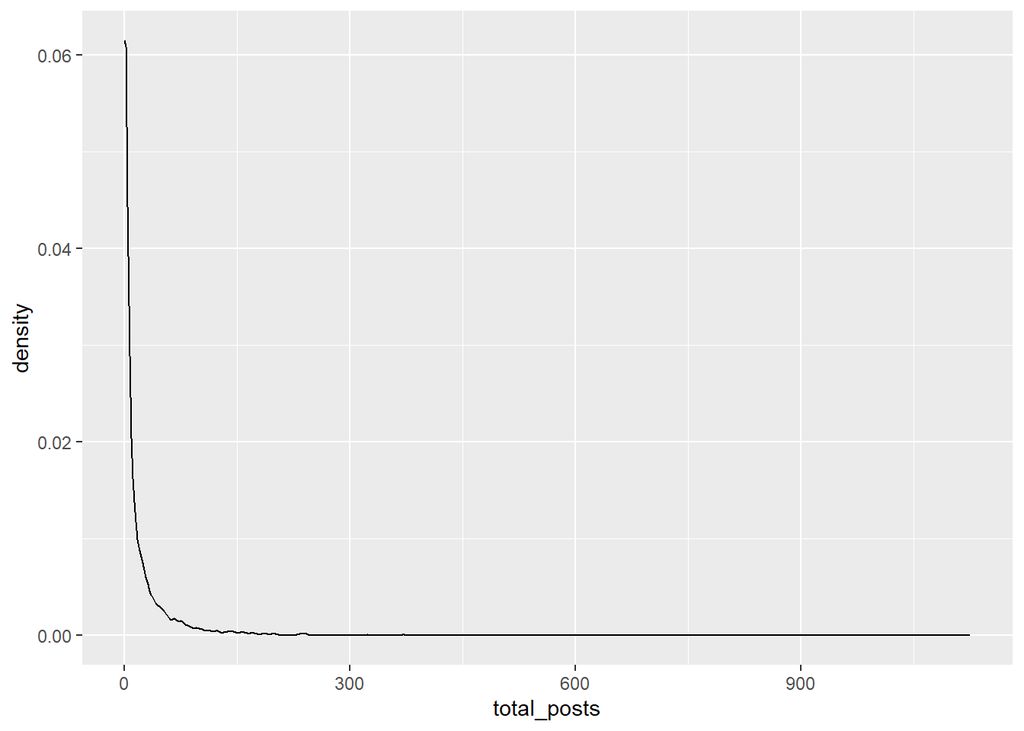

```r
gg<-ggplot(za, aes(x=total_posts))+
  geom_density()
gg
```

`raop_posts`,

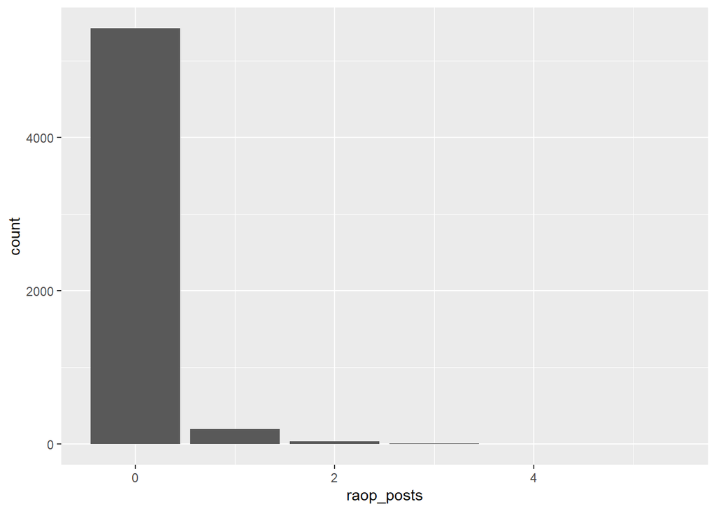

```r
gg<-ggplot(za, aes(x=raop_posts))+
  geom_bar()
gg
```

`student`,

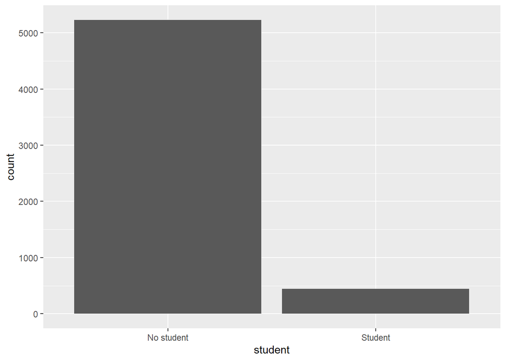

```r
gg<-ggplot(za, aes(x=student))+
  geom_bar()
gg
```

`grateful`,

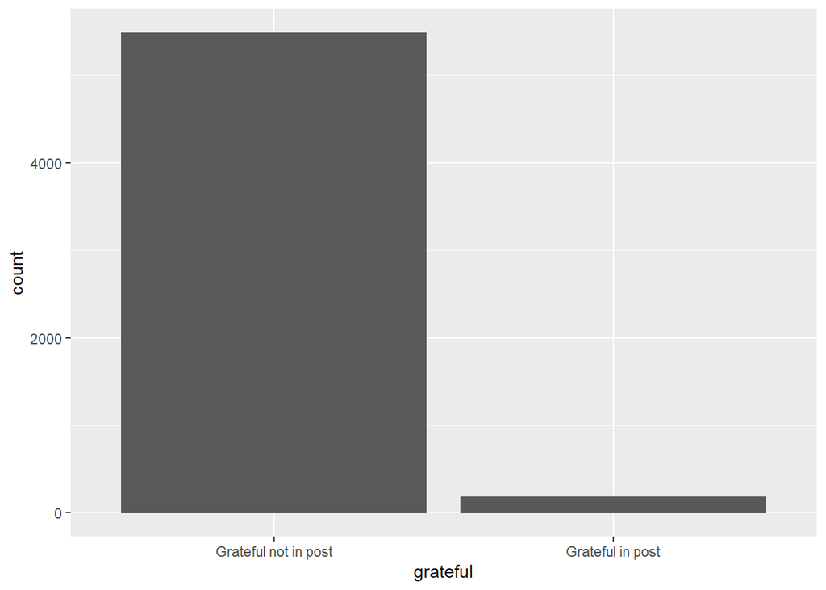

```r
gg<-ggplot(za, aes(x=grateful))+
  geom_bar()
gg
```

`pop_request`,

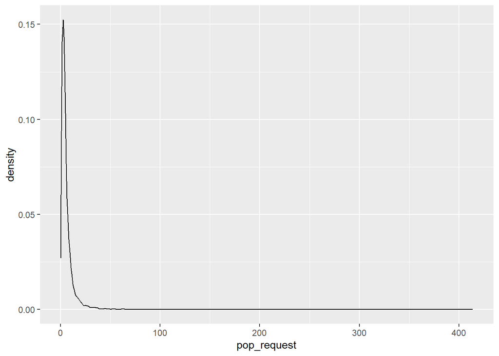

```r
gg<-ggplot(za, aes(x=pop_request))+
  geom_density()
gg
```

and `score`.

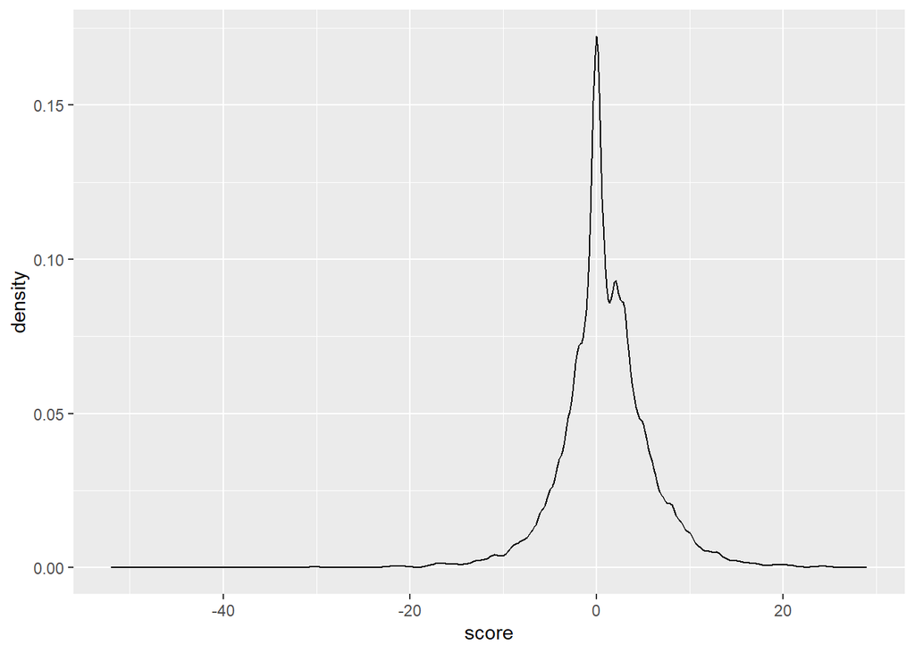

```r
gg<-ggplot(za, aes(x=score))+
  geom_density()
gg
```

How do we feel about these distributions? Do they look like they will be good predictors?

### Step 2: Split the Data

#### Testing and Training

```r
#Before I split these, I'm going to go ahead and drop the 3 observations that are missing on my outcome variable - got pizza; this way I won't chance having all three missing in one of my datasets. While 3 observations really aren't going to throw anything way off - I know they're not going to be included in my analyses, so I'm dropping them.
za<-za%>%
  filter(!is.na(got_pizza_f))

set.seed(1025)

za_split<-initial_split(za, prop=.5)

za_train<-training(za_split)

za_test<-testing(za_split)
```

### Step 3: Begin a Workflow

Next we setup a new workflow.

```r
logit_wf<-workflow()
```

### Step 4: Specify the Formula

Next we set up the terms of the model.

```r
# Model terms
za_formula<-as.formula("got_pizza_f ~
             age +
             karma +
             total_posts +
             raop_posts +
             student +
             grateful +
             pop_request +
             score")
```

### Step 5: Specify the Model

Now we’re going to specify the model. This approach is a little different than what we’ve been using up until now. We’re going to create a `logit_mod` object by fitting a logistic regression to our outcome. The `set_engine` function says what particular kind of logistic regression we want to fit– in this case we want to do classification (or “glm”).

```r
logit_mod <-
  logistic_reg() %>%
  set_engine("glm")%>%
  set_mode("classification")
```

### Step 6: Set/Update Recipe

Next we’ll set up the recipe.

```r
logit_rec<-recipe(za_formula, data=za)%>%
  step_dummy(grateful,student)%>%
  step_log(age, offset = abs(min(za$age))+1, base=10)%>%
  step_log(karma, offset = abs(min(za$karma))+1, base=10)%>%
  step_log(total_posts, offset = abs(min(za$total_posts))+1, base=10)%>%
  step_log(pop_request, offset = abs(min(za$pop_request))+1, base=10)
```

Notice the use of a log function for total posts, which follow a classic exponential distribution. We use `offset=1` to avoid attempting to take the log of 0 (which is undefined). Additionally, by changing to `base=10` we increase our interpretability. This means that an increase of one unit results in ten-fold increase in real terms.

### Step 7: Assemble Workflow

Put the workflow together

```r
logit_wf<-logit_wf%>%
  add_recipe(logit_rec)%>%
  add_model(logit_mod)
```

### Step 8: Fit the Model to the Data

Fit the model to the training dataset

```r
logit_results<-fit(logit_wf, data=za_train)
```

```r
logit_results%>%
  tidy()
```

```
## # A tibble: 9 × 5
##   term                       estimate std.error statistic  p.value
##   <chr>                         <dbl>     <dbl>     <dbl>    <dbl>
## 1 (Intercept)               -2.42       0.352     -6.88   5.92e-12
## 2 age                        0.227      0.0629     3.60   3.13e- 4
## 3 karma                      0.0116     0.150      0.0776 9.38e- 1
## 4 total_posts               -0.109      0.128     -0.848  3.96e- 1
## 5 raop_posts                 0.829      0.138      6.00   1.93e- 9
## 6 pop_request                1.13       0.147      7.65   1.98e-14
## 7 score                     -0.000675   0.00892   -0.0756 9.40e- 1
## 8 grateful_Grateful.in.post  0.295      0.227      1.30   1.93e- 1
## 9 student_Student            0.304      0.160      1.90   5.78e- 2
```

```r
#SUPPLEMENTAL code for producing a prettier (IMO, more easily understood) table
library(gtsummary) #we will take advantage of the gtsummary package (https://www.danieldsjoberg.com/gtsummary/index.html)
tbl_regression(logit_results, exponentiate=T, intercept=T)%>% #note: ONLY use exponentiate when your outcome is binary (not continuous)
    bold_p() %>%
  bold_labels() %>%
  italicize_levels()%>%
    as_flex_table()
```

```
## Extracting {workflows} model fit with `workflows::extract_fit_parsnip(x) %>% tbl_regression(...)`
```

```
## Extracting {parsnip} model fit with `tbl_regression(x = x$fit, ...)`
```

| Characteristic | OR1 | 95% CI1 | p-value |
| --- | --- | --- | --- |
| (Intercept) | 0.09 | 0.04, 0.18 | <0.001 |
| age | 1.25 | 1.11, 1.42 | <0.001 |
| karma | 1.01 | 0.75, 1.36 | >0.9 |
| total_posts | 0.90 | 0.70, 1.15 | 0.4 |
| raop_posts | 2.29 | 1.76, 3.03 | <0.001 |
| pop_request | 3.08 | 2.31, 4.12 | <0.001 |
| score | 1.00 | 0.98, 1.02 | >0.9 |
| grateful_Grateful.in.post | 1.34 | 0.85, 2.07 | 0.2 |
| student_Student | 1.36 | 0.98, 1.85 | 0.058 |

1OR = Odds Ratio, CI = Confidence Interval

### Step 9: Predict the Testing Data

With these results in hand we can generate predicted classifications.

We can convert the predictions to a binary variable by setting a “threshold” of .5. Any prediction above .5 is considered to be a 1, anything below, a 0. We’ll compare the actual “truth” of whether or not someone got a pizza with our prediction from the model using what’s called a “confusion matrix” (really).

```r
logit_results%>%
  predict(za_test)%>%
  bind_cols(za_test)%>%
  conf_mat(truth=got_pizza_f, estimate=.pred_class)
```

```
##           Truth
## Prediction   No  Yes
##        No  2100  673
##        Yes   23   32
```

### Step 10: Calculate Fit

We’re usually interested in three things: the overall accuracy of a classification is the proportion of cases accurately classified. The sensitivity is the proportion of “ones” that are accurately classified as ones– it’s the probability that a case classified as positive will indeed be positive. Specificity is the probability that a case classified as 0 will indeed be 0.

#### Accuracy: proportion correctly identifed

```r
logit_results%>%
  predict(za_test)%>%
  dplyr::bind_cols(za_test)%>%
  metrics(truth=got_pizza_f, estimate=.pred_class)
```

```
## # A tibble: 2 × 3
##   .metric  .estimator .estimate
##   <chr>    <chr>          <dbl>
## 1 accuracy binary        0.754
## 2 kap      binary        0.0499
```

#### Sensitivity, probability of saying it’s a “yes” when it’s really a “yes” (true positive)

```r
logit_results%>%
  predict(za_test)%>%
  bind_cols(za_test)%>%
 sens(truth=got_pizza_f, estimate=.pred_class, event_level="second")
```

```
## # A tibble: 1 × 3
##   .metric .estimator .estimate
##   <chr>   <chr>          <dbl>
## 1 sens    binary        0.0454
```

#### Specificity, probability of saying it’s a “No” when it’s really a “No” (true negative)

```r
logit_results%>%
  predict(za_test)%>%
  bind_cols(za_test)%>%
  spec(truth=got_pizza_f, estimate=.pred_class, event_level="second")
```

```
## # A tibble: 1 × 3
##   .metric .estimator .estimate
##   <chr>   <chr>          <dbl>
## 1 spec    binary         0.989
```

*Question: how do you get perfect specificity? How do you get perfect sensitivity?*

#### Area Under the Curve (AUC)

##### Thresholds

As we vary the threshold from 0 to 1, the sensitivity will decrease, while the specificity will increase. The best models will be able to have both high sensitivity and specificity at a threshold. The code below shows what happens to sensitivity and specificity as thresholds go from 0 to 1.

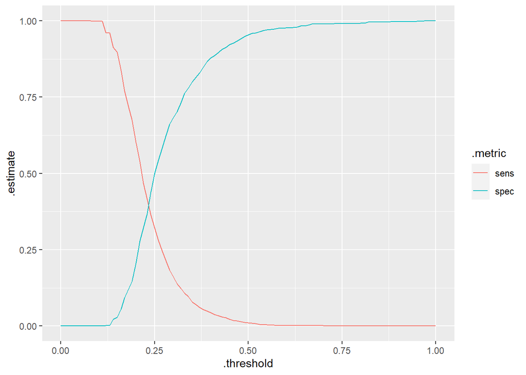

```r
#adding code from below here - I want to save my predictions as a dataset, so we can look at it (and I want to do it here rather than later in my code):
logit_final<-last_fit(logit_wf, za_split)
predictions<-as.data.frame(logit_final$.predictions) #save predictions as dataset

th<-logit_results%>%
  predict(za_test, type="prob")%>%
  bind_cols(za_test)%>%
   threshold_perf(truth=got_pizza_f,
                 estimate=.pred_Yes,
                 thresholds=seq(0, 1, by=.01), metrics=c("sens","spec"))

ggplot(filter(th, .metric%in%c("sens", "spec")),
       aes(x=.threshold, y=.estimate, color=.metric))+
  geom_line()
```

The area under the curve considers both the sensitivity (does the model accurately predict every positive outcome) with the specificity (does the model accurately predict every negative outcome) for a given model, and does so across every possible threshold value.

```r
logit_results%>%
  predict(za_test, type="prob")%>%
  bind_cols(za_test)%>%
  roc_auc(truth=got_pizza_f, .estimate=.pred_Yes, event_level="second")
```

```
## # A tibble: 1 × 3
##   .metric .estimator .estimate
##   <chr>   <chr>          <dbl>
## 1 roc_auc binary         0.647
```

```r
#ROC - receiver operating characteristic
```

We got an ROC of .65 Our goal would be at least .7; so our model clearly isn’t doing a great job of balancing sens/spec (which we already knew).

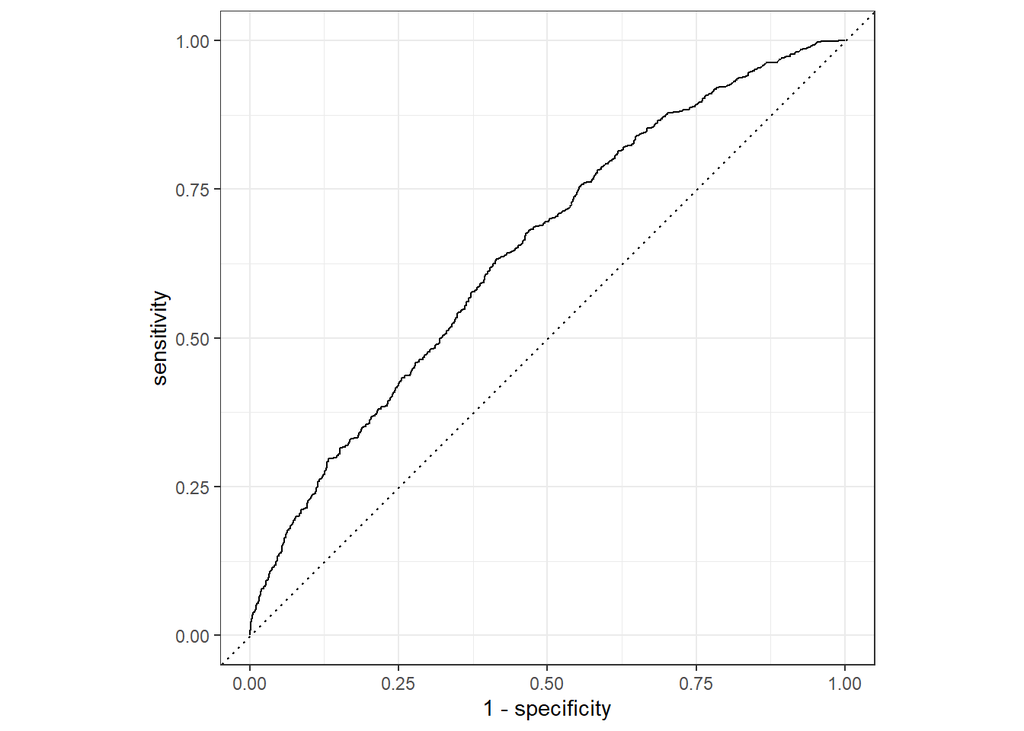

```r
logit_results%>%
  predict(za_test,type="prob")%>%
  bind_cols(za_test)%>%
  roc_curve(truth=got_pizza_f, .estimate=.pred_Yes, event_level="second")%>%
  autoplot()
```

[Here’s a nice visual to aid in interpreting these plots:](https://en.wikipedia.org/wiki/Receiver_operating_characteristic#/media/File:Roc-draft-xkcd-style.svg)

## Use “last fit” to get same results on our logit_final object.

```r
#I moved the next two lines of code up to the beginning of this week's file so that we could examine the predictions. Commenting them out here.

#logit_final<-last_fit(logit_wf, za_split)
#predictions<-as.data.frame(logit_final$.predictions) #save predictions as dataset

logit_final$.metrics
```

```
## [[1]]
## # A tibble: 2 × 4
##   .metric  .estimator .estimate .config
##   <chr>    <chr>          <dbl> <chr>
## 1 accuracy binary         0.754 Preprocessor1_Model1
## 2 roc_auc  binary         0.647 Preprocessor1_Model1
```

# What if I want to modify my threshold to attempt to get a more balanced sensitivity and specificity?

```r
#first - I want to change my predicted class values
predictions$.pred_class2=ifelse(predictions$.pred_Yes>.24,"Yes","No") #modify threshold to .24

table(predictions$got_pizza_f, predictions$.pred_class2) #examine new confusion matrix
```

```
##
##         No  Yes
##   No  1349  774
##   Yes  309  396
```

```r
#note, I'm just calculating these "by hand" here
#accuracy - how many obs did we predict correctly?
(1349+396)/(1349+774+309+396) #our accuracy went down -- how come?
```

```
## [1] 0.6170438
```

```r
#sensitivity - the number of correct positive (YESs) predictions divided by the total number of actual positives
396/(309+396) #we got better sensitivity here
```

```
## [1] 0.5617021
```

```r
#specificity - the number of correct negative (NOs) predictions divided by the total number of actual negatives
1349/(1349+774) #but we had to sacrifice some specificity
```

```
## [1] 0.6354216
```

```r
###################################

#Another way of doing it.
cMatrix<-table(predictions$got_pizza_f, predictions$.pred_class2)

#accuracy - how many obs did we predict correctly?
covidjobs_Acc<-(cMatrix[1,1] + cMatrix[2,2])/(sum(rowSums(cMatrix)))
names(covidjobs_Acc)<-"Accuracy"

#sensitivity - the number of correct positive (YESs) predictions divided by the total number of actual positives
covidjobs_Sen<-cMatrix[2,2]/(rowSums(cMatrix)[2])
names(covidjobs_Sen)<-"Sensitivity"

#specificity - the number of correct negative (NOs) predictions divided by the total number of actual negatives
covidjobs_Spe<-cMatrix[1,1]/(rowSums(cMatrix)[1])
names(covidjobs_Spe)<-"Specificity"

logModFit<-cbind(covidjobs_Acc,covidjobs_Sen,covidjobs_Spe)
rownames(logModFit)<-"Got Pizza?"
logModFit
```

```
##            covidjobs_Acc covidjobs_Sen covidjobs_Spe
## Got Pizza?     0.6170438     0.5617021     0.6354216
```

# Plotting results from logistic regression

Because individual coefficients are so hard to understand, most of the time we convert the results to predicted probabilities, using a range of hypothetical values, as in the code below.

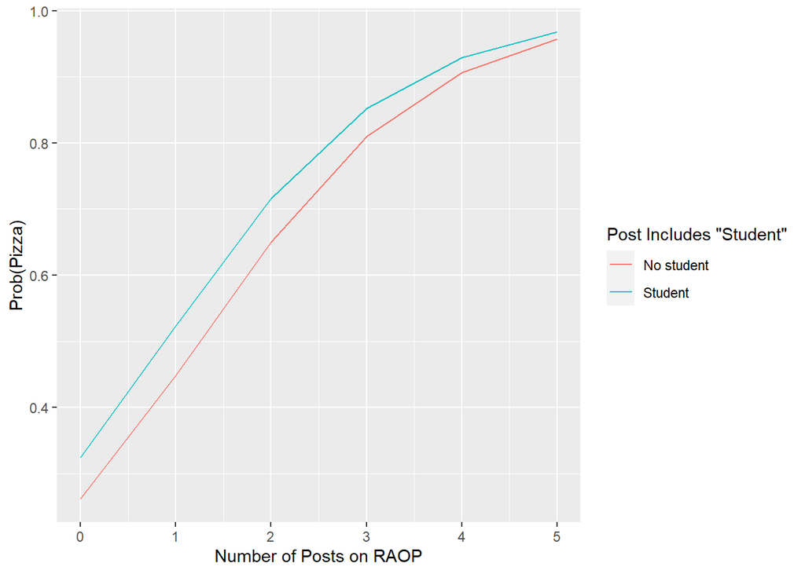

```r
hypo_data<-za_train%>%
  data_grid(
    age=mean(age, na.rm=TRUE),
    karma=as.integer(mean(karma, na.rm=TRUE)),
    total_posts=as.integer(mean(total_posts, na.rm=TRUE)),
    raop_posts=as.integer(seq_range(raop_posts, n=100)),
    student=as_factor(levels(student)),
    grateful=as_factor(levels(grateful)[1]),
    pop_request=as.integer(mean(pop_request, na.rm=TRUE)),
    score=mean(score, na.rm=TRUE)
)

plot_data<-logit_results%>%
  predict(hypo_data, type="prob")%>%
  bind_cols(hypo_data)%>%
  rename(`Post Includes "Student"`=student)

plot_data%>%
ggplot(aes(x=raop_posts, y=.pred_Yes, color=`Post Includes "Student"`))+
  geom_line()+
  xlab("Number of Posts on RAOP")+
  ylab("Prob(Pizza)")
```